# Physical Activity Level and Performance of Pelvic Floor Muscle Exercises

### Results

See why people report doing PFM exercises (kegel_91) and how they learned about them (kegel_92). Will look at the distribution of answers to these questionnaire items.

##### kegel_91: Why did you start doing Kegels or pelvic exercises? Check all that apply.

```r
#Look at distribution of answers for kegel_91
table(bladderhealth_kegel_91.df$kegel_91)
```

```
##
##                      I was told to start after childbirth
##                                                       314
##                   To treat my urine leakage/bladder leaks
##                                                       230
##                                  To treat urinary urgency
##                                                        87
##                                 To treat my bowel problem
##                                                        25
##                                            To improve sex
##                                                       452
##                              To prevent getting a problem
##                                                       311
## Because my doctor, nurse or therapist suggested I do them
##                                                       266
## Because a friend or family member suggested me to do them
##                                                       217
##     Because a magazine or website suggested me to do them
##                                                       299
##                                                     Other
##                                                        88
```

```r
#Convert these numbers to percentages of total women surveyed (1748)
list <- table(bladderhealth_kegel_91.df$kegel_91)
lapply(list, function(x) x/1748*100)
```

```
## $`I was told to start after childbirth`
## [1] 17.96339
##
## $`To treat my urine leakage/bladder leaks`
## [1] 13.15789
##
## $`To treat urinary urgency`
## [1] 4.977117
##
## $`To treat my bowel problem`
## [1] 1.430206
##
## $`To improve sex`
## [1] 25.85812
##
## $`To prevent getting a problem`
## [1] 17.79176
##
## $`Because my doctor, nurse or therapist suggested I do them`
## [1] 15.21739
##
## $`Because a friend or family member suggested me to do them`
## [1] 12.41419
##
## $`Because a magazine or website suggested me to do them`
## [1] 17.10526
##
## $Other
## [1] 5.034325
```

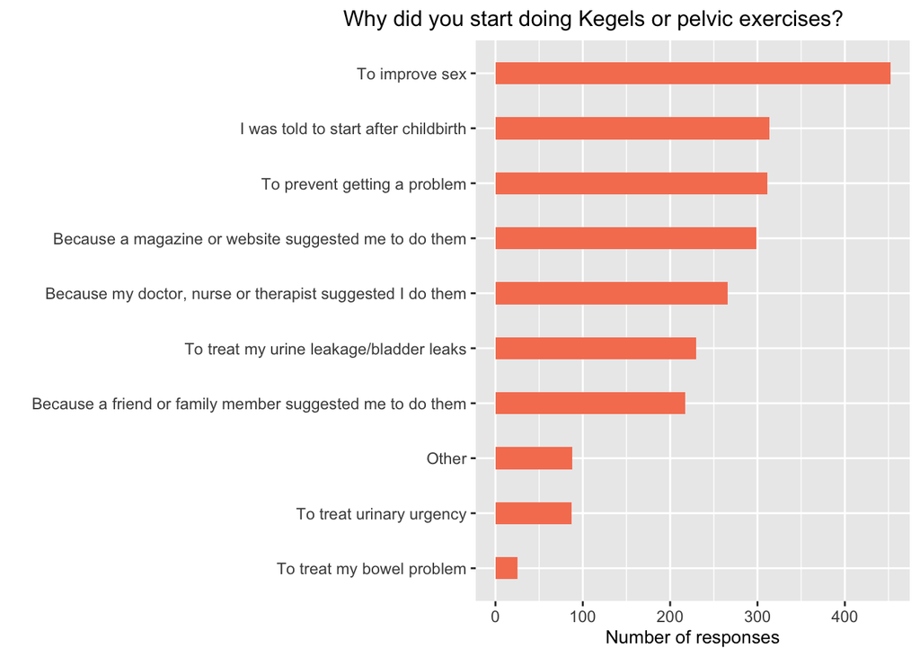

```r
#kegel_91___1: "I was told to start after childbirth": 314, 18.0%
#kegel_92___2: "To treat my urine leakage/bladder leaks": 230, 13.2%
#kegel_91___3: "To treat urinary urgency": 87, 5.0%
#kegel_91___4 = "To treat my bowel problem": 25, 1.4%
#kegel_91___5 = "To improve sex": 452, 25.9%
#kegel_91___6 = "To prevent getting a problem": 311, 17.8%
#kegel_91___7 = "Because my doctor, nurse or therapist suggested I do them": 266, 15.2%
#kegel_91___8 = "Because a friend or family member suggested me to do them": 217, 12.4%
#kegel_91___9 = "Because a magazine or website suggested me to do them": 299, 17.1%
#kegel_91___10 = "Other": 88, 5.0%

#Bar plot to visualize distributions of answers to kegel_91
ggplot(bladderhealth_kegel_91.df, aes(x = reorder(kegel_91, kegel_91, function(x) length(x)))) +
  geom_bar(fill="#f68060", alpha= 1, width=.4) +
  ggtitle("Why did you start doing Kegels or pelvic exercises?") +
  xlab("") +
  ylab("Number of responses") +
  theme(plot.title = element_text(hjust = 2, color = "black", size = 12)) +
  theme(axis.title.x = element_text(color = "black", size = 10)) +
  theme(axis.title.y = element_text(color = "black", size = 10)) +
  theme(legend.title = element_blank()) +
  coord_flip()
```

```r
#Save graph.
ggsave("Supplemental Fig 1 - Reasons for Kegels.tiff", units="in", width=6, height=4, dpi=300)
```

The top 3 reasons given for doing PFM exercises were to improve sex (25.9%), to prevent getting a problem (17.8%), and being instructed to start doing them after childbirth (18.0%).

##### kegel_92: How did you learn about Kegels or pelvic muscle exercises? Check all that apply.

```r
#Look at distribution of answers for kegel_92
table(bladderhealth_kegel_92.df$kegel_92)
```

```
##
##              A book/magazine       A pamphlet or brochure
##                          504                          105
##            An online website A doctor, nurse or therapist
##                          349                          608
##         A fitness instructor    A friend or family member
##                          104                          454
##                        Other
##                          169
```

```r
#Convert these numbers to percentages of total women surveyed (1748)
list <- table(bladderhealth_kegel_92.df$kegel_92)
lapply(list, function(x) x/1748*100)
```

```
## $`A book/magazine`
## [1] 28.83295
##
## $`A pamphlet or brochure`
## [1] 6.006865
##
## $`An online website`
## [1] 19.96568
##
## $`A doctor, nurse or therapist`
## [1] 34.78261
##
## $`A fitness instructor`
## [1] 5.949657
##
## $`A friend or family member`
## [1] 25.97254
##
## $Other
## [1] 9.668192
```

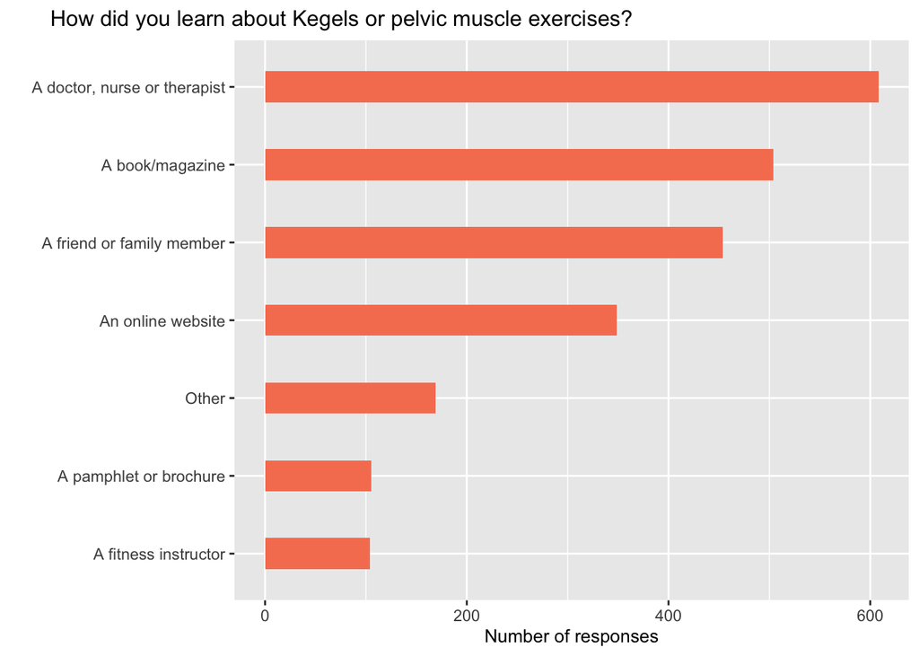

```r
#kegel_92___1 = "A book/magazine": 504, 28.8%
#kegel_92___2 = "A pamphlet or brochure": 105, 6.0%
#kegel_92___3 = "An online website": 349, 20.0%
#kegel_92___4 = "A doctor, nurse or therapist": 608, 34.8%
#kegel_92___5 = "A fitness instructor": 104: 5.9%
#kegel_92___6 = "A friend or family member": 454, 26.0%
#kegel_92___7 = "Other": 169, 9.7%

#Bar plot to visualize distributions of answers to kegel_92
ggplot(bladderhealth_kegel_92.df, aes(x = reorder(kegel_92, kegel_92, function(x) length(x)))) +
  geom_bar(fill="#f68060", alpha= 1, width=.4) +
  ggtitle("How did you learn about Kegels or pelvic muscle exercises?") +
  xlab("") +
  ylab("Number of responses") +
  theme(plot.title = element_text(hjust = -2, color = "black", size = 12)) +
  theme(axis.title.x = element_text(color = "black", size = 10)) +
  theme(axis.title.y = element_text(color = "black", size = 10)) +
  theme(legend.title = element_blank()) +
  coord_flip()
```

```r
#Save graph.
ggsave("Supplemental Fig 2 - Kegels by learning source.tiff", units="in", width=6, height=4, dpi=300)
```

The top 3 sources of information about PFM exercises were a doctor, nurse, or therapist (34.8%); a book or magazine (28.8%), and a friend or family member (26.0%).

#### Primary outcome

Frequency of doing PFM exercises compared between IPAQ groups (i.e. responses to the following questionnaire item compared between IPAQ groups). Will look at distribution of answers, then compare distribution between IPAQ groups using the Kruskal-Wallis test.

##### kegel_89: Do you do Kegels or pelvic muscle exercises?

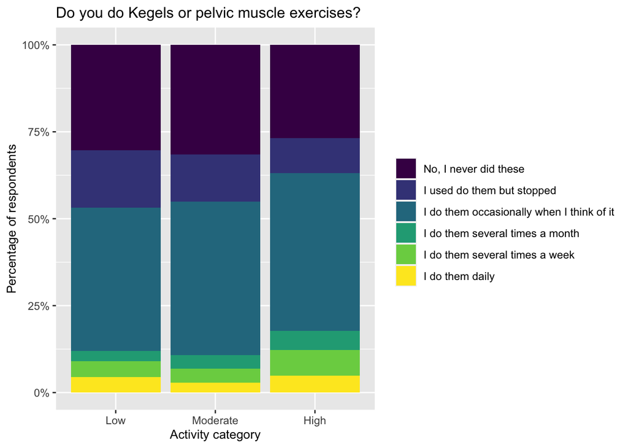

```r
#Evaluate the distribution of kegel_89 answers among the 3 IPAQ categories (high, moderate, low).
ggplot(bladderhealth_kegel_89.df, aes(fill = kegel_89, x = ipaq)) + geom_bar(position = "fill") + ggtitle("Do you do Kegels or pelvic muscle exercises?") +
xlab("Activity category") +
ylab("Percentage of respondents") +
theme(plot.title = element_text(color = "black", size = 12)) +
theme(axis.title.x = element_text(color = "black", size = 10)) +
theme(axis.title.y = element_text(color = "black", size = 10)) +
scale_x_discrete(labels = c("low" = "Low", "moderate" = "Moderate", "high" = "High")) + scale_y_continuous(labels = scales::percent) +
  theme(legend.title = element_blank())
```

Women in the high activity group appear to be more likely to do PFM exercises several times a month or more.

```r
#Save graph.
ggsave("Fig 1 - Kegels by IPAQ category.tiff", units="in", width=6, height=4, dpi=300)

#Get numbers for each category
table(bladderhealth_kegel_89.df$kegel_89, bladderhealth_kegel_89.df$ipaq)
```

```
##
##                                             Low Moderate High
##   No, I never did these                     243      141  121
##   I used do them but stopped                133       61   45
##   I do them occasionally when I think of it 330      198  204
##   I do them several times a month            24       17   25
##   I do them several times a week             36       18   33
##   I do them daily                            36       13   22
```

```r
#Get proportions for each category
prop.table(table(bladderhealth_kegel_89.df$kegel_89, bladderhealth_kegel_89.df$ipaq), 2)
```

```
##
##                                                    Low   Moderate       High
##   No, I never did these                     0.30299252 0.31473214 0.26888889
##   I used do them but stopped                0.16583541 0.13616071 0.10000000
##   I do them occasionally when I think of it 0.41147132 0.44196429 0.45333333
##   I do them several times a month           0.02992519 0.03794643 0.05555556
##   I do them several times a week            0.04488778 0.04017857 0.07333333
##   I do them daily                           0.04488778 0.02901786 0.04888889
```

```r
#Kruskal-Wallis test for ipaq and pa_89:
kruskal.test(bladderhealth_kegel_89.df$kegel_89, bladderhealth_kegel_89.df$ipaq)
```

```
##
##  Kruskal-Wallis rank sum test
##
## data:  bladderhealth_kegel_89.df$kegel_89 and bladderhealth_kegel_89.df$ipaq
## Kruskal-Wallis chi-squared = 12.069, df = 2, p-value = 0.002395
```

```r
#The distribution of answers is significantly different between IPAQ categories (p = 0.002395).

#For all groups, how many report doing PFMs several times a month or more?
bladderhealth_kegel_89.df %>% count(kegel_89 == "I do them several times a month" | kegel_89 == "I do them several times a week" | kegel_89 == "I do them daily") #224/1700*100 = 13.2%
```

```
##   ... | kegel_89 == "I do them daily"    n
## 1                               FALSE 1476
## 2                                TRUE  224
```

```r
#For each IPAQ group, how many report doing PFMs several times a month or more?
bladderhealth_kegel_89.df %>% group_by(ipaq) %>% count(kegel_89 == "I do them several times a month" | kegel_89 == "I do them several times a week" | kegel_89 == "I do them daily")
```

```
## # A tibble: 6 × 3
## # Groups:   ipaq [3]
##   ipaq     `... | kegel_89 == "I do them daily"`     n
##   <fct>    <lgl>                                 <int>
## 1 Low      FALSE                                   706
## 2 Low      TRUE                                     96
## 3 Moderate FALSE                                   400
## 4 Moderate TRUE                                     48
## 5 High     FALSE                                   370
## 6 High     TRUE                                     80
```

```r
#Low = 96/(706+96)*100 = 12.0%
#Moderate = 48/(400+48)*100 = 10.7%
#High = 80/(370+80)*100 = 17.8%

#Confirm that when condensing outcome categories for doing PFM exercises "several times a month or more," categories are still significantly different among IPAQ groups.
bladderhealth_kegel_89_condensed.df <- bladderhealth_kegel_89.df %>% mutate(kegel_89 = fct_collapse(kegel_89, "I do them several times a month or more" = c("I do them several times a month", "I do them several times a week", "I do them daily")))
kruskal.test(bladderhealth_kegel_89_condensed.df$kegel_89, bladderhealth_kegel_89_condensed.df$ipaq)
```

```
##
##  Kruskal-Wallis rank sum test
##
## data:  bladderhealth_kegel_89_condensed.df$kegel_89 and bladderhealth_kegel_89_condensed.df$ipaq
## Kruskal-Wallis chi-squared = 12.395, df = 2, p-value = 0.002034
```

```r
#Still significant, p = 0.002034.
```

#### Secondary outcomes

For each item, look at distribution of answers, then compare distribution between IPAQ groups using the Kruskal-Wallis test.

##### kegel_86: Have you ever heard of Kegel exercises?

##### kegel_87: Have you heard of pelvic exercises or pelvic floor muscle exercises?

```r
#How many women have heard of Kegels (kegel_86) or PFMs (kegel_87)?
bladderhealth_kegel_86_87.df %>% count(kegel_86 == "Yes, I know what they are" | kegel_86 == "Yes, I've heard of them but I don't know what they are" | kegel_87 == "Yes, I know what they are" | kegel_87 == "Yes, I've heard of them but I don't know what they are")
```

```
##   ... | ...    n
## 1     FALSE   45
## 2      TRUE 1652
```

```r
#1652 have heard of Kegels or PFMs, but may or may not know what they are. 1652/1697*100 = 97.3%

#How many women have heard of Kegels (kegel_86) or PFMs (kegel_87) AND know what they are?
bladderhealth_kegel_86_87.df %>% count(kegel_86 == "Yes, I know what they are" | kegel_87 == "Yes, I know what they are")
```

```
##   kegel_86 == "Yes, I know what they are" | ...    n
## 1                                         FALSE  178
## 2                                          TRUE 1519
```

```r
#1519 have both heard of them and know what they are. 1519/1697*100 = 89.5%

#Are the responses to kegel_86 different between IPAQ groups?
kruskal.test(bladderhealth_kegel_86.df$kegel_86, bladderhealth_kegel_86.df$ipaq) #no, p = 0.5493
```

```
##
##  Kruskal-Wallis rank sum test
##
## data:  bladderhealth_kegel_86.df$kegel_86 and bladderhealth_kegel_86.df$ipaq
## Kruskal-Wallis chi-squared = 1.1984, df = 2, p-value = 0.5493
```

```r
#Are the responses to kegel_87 different between IPAQ groups?
kruskal.test(bladderhealth_kegel_87.df$kegel_87, bladderhealth_kegel_87.df$ipaq) #yes, p = 0.006639
```

```
##
##  Kruskal-Wallis rank sum test
##
## data:  bladderhealth_kegel_87.df$kegel_87 and bladderhealth_kegel_87.df$ipaq
## Kruskal-Wallis chi-squared = 10.03, df = 2, p-value = 0.006639
```

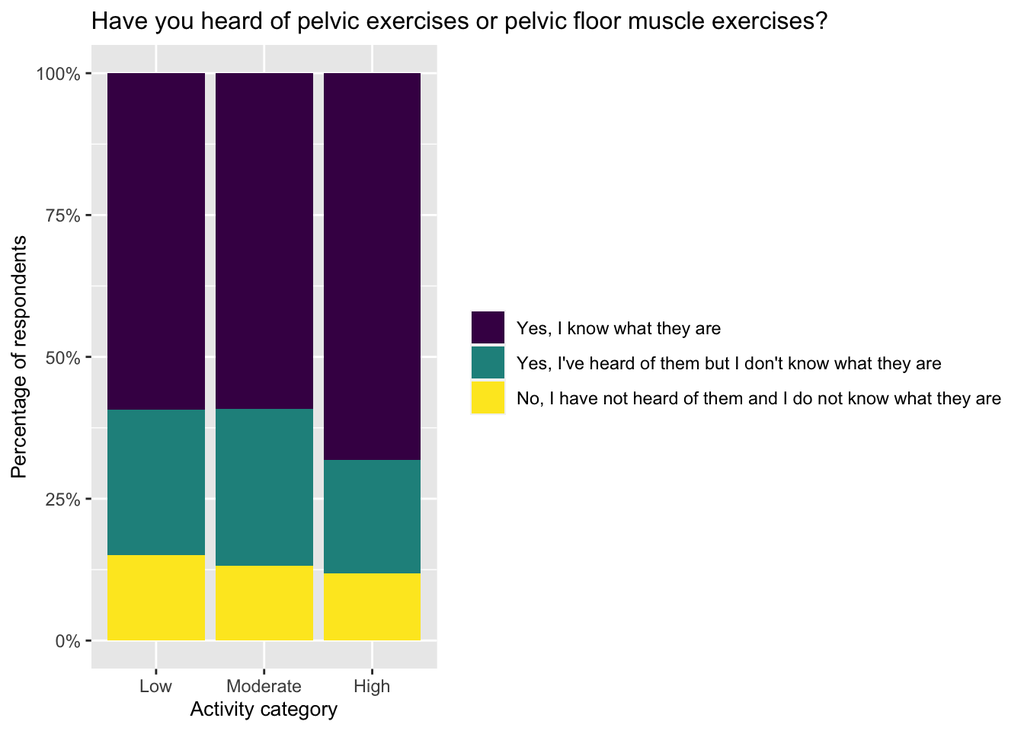

```r
#Will use proportional stacked bar plot to better visualize distribution for kegel_87 among IPAQ groups.
ggplot(bladderhealth_kegel_87.df, aes(fill = as.factor(kegel_87), x = ipaq)) + geom_bar(position = "fill") + ggtitle("Have you heard of pelvic exercises or pelvic floor muscle exercises?") +
xlab("Activity category") +
ylab("Percentage of respondents") +
theme(plot.title = element_text(color = "black", size = 12)) +
theme(axis.title.x = element_text(color = "black", size = 10)) +
theme(axis.title.y = element_text(color = "black", size = 10)) +
scale_x_discrete(labels = c("low" = "Low", "moderate" = "Moderate", "high" = "High")) + scale_y_continuous(labels = scales::percent) +
  theme(legend.title = element_blank())
```

```r
#Save graph.
ggsave("Supplemental Fig 3 - Heard of Kegels by IPAQ category.tiff", units="in", width=6, height=4, dpi=300)
```

97.3% of women had heard of Kegels or PFM exercises, and 89.5% of women had both heard of them and knew what they were. Compared to women in the low and moderate physical activity groups, women in the high physical activity group were more likely to know what “PFM exercises” were, but not “Kegel exercises.”

##### kegel_89b: Why don’t you do Kegels or pelvic muscle exercises more?

```r
table(bladderhealth_kegel_89b.df$kegel_89b)
```

```
##
##         I don't need to   They're too difficult They take too much time
##                     169                      20                      17
##  They don't help enough            I'm too lazy                   Other
##                     134                     291                     405
```

```r
#Most women said other (405/1036, 39.1%), 2nd most said I'm too lazy (291/1036, 28.1%), then I don't need to (169/1036, 16.3%) and they don't help enough (134/1036, 12.9%). Very few said they were too difficult (20/1036, 1.9%) or take too much time (17/1036, 1.6%).

#Are the responses to kegel_89b different between IPAQ groups?
kruskal.test(bladderhealth_kegel_89b.df$kegel_89b, bladderhealth_kegel_89b.df$ipaq) #no, p = 0.1203.
```

```
##
##  Kruskal-Wallis rank sum test
##
## data:  bladderhealth_kegel_89b.df$kegel_89b and bladderhealth_kegel_89b.df$ipaq
## Kruskal-Wallis chi-squared = 4.2356, df = 2, p-value = 0.1203
```

```r
#Excluding "other" as a reason for not doing Kegels, did the answers differ between IPAQ groups?
kruskal.test(bladderhealth_kegel_89b_specific.df$kegel_89b_specific, bladderhealth_kegel_89b_specific.df$ipaq) #yes, p = 0.02.
```

```
##
##  Kruskal-Wallis rank sum test
##
## data:  bladderhealth_kegel_89b_specific.df$kegel_89b_specific and bladderhealth_kegel_89b_specific.df$ipaq
## Kruskal-Wallis chi-squared = 7.6729, df = 2, p-value = 0.02157
```

```r
#Get numbers for each category
table(bladderhealth_kegel_89b_specific.df$kegel_89b_specific, bladderhealth_kegel_89b_specific.df$ipaq)
```

```
##
##                           Low Moderate High
##   I don't need to          70       41   58
##   They're too difficult    12        4    4
##   They take too much time   5        2   10
##   They don't help enough   65       35   34
##   I'm too lazy            138       86   67
```

```r
#Get proportions for each category
prop.table(table(bladderhealth_kegel_89b_specific.df$kegel_89b_specific, bladderhealth_kegel_89b_specific.df$ipaq), 2)
```

```
##
##                                  Low   Moderate       High
##   I don't need to         0.24137931 0.24404762 0.33526012
##   They're too difficult   0.04137931 0.02380952 0.02312139
##   They take too much time 0.01724138 0.01190476 0.05780347
##   They don't help enough  0.22413793 0.20833333 0.19653179
##   I'm too lazy            0.47586207 0.51190476 0.38728324
```

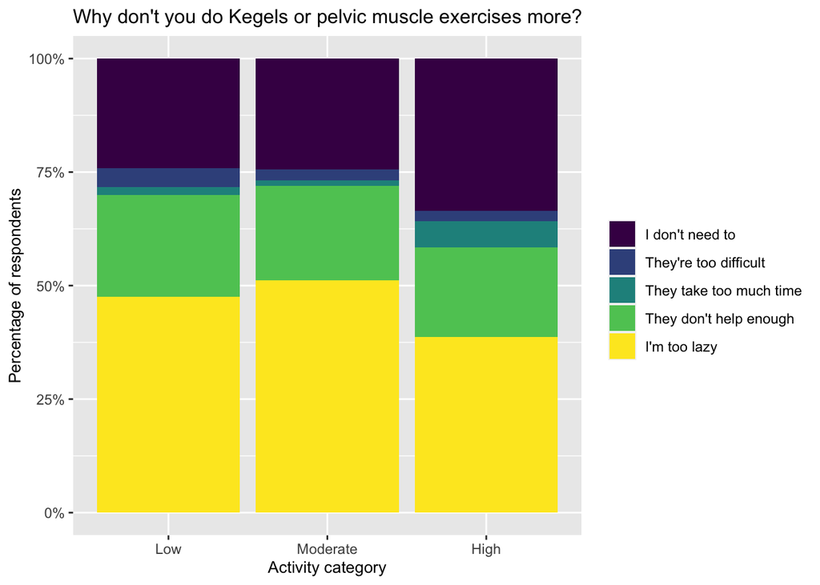

```r
#Will use proportional stacked bar plot to better visualize distribution for kegel_89b_specific among IPAQ groups.
ggplot(bladderhealth_kegel_89b_specific.df, aes(fill = kegel_89b_specific, x = ipaq)) + geom_bar(position = "fill") + ggtitle("Why don't you do Kegels or pelvic muscle exercises more?") +
xlab("Activity category") +
ylab("Percentage of respondents") +
theme(plot.title = element_text(color = "black", size = 12)) +
theme(axis.title.x = element_text(color = "black", size = 10)) +
theme(axis.title.y = element_text(color = "black", size = 10)) +
scale_x_discrete(labels = c("low" = "Low", "moderate" = "Moderate", "high" = "High")) + scale_y_continuous(labels = scales::percent) +
  theme(legend.title = element_blank())
```

```r
#Save graph.
ggsave("Fig 2 - Reasons for not doing Kegels by IPAQ category.tiff", units="in", width=6, height=4, dpi=300)
```

While the top reason given for not doing Kegels or PFM exercises more was “other” (39.1%), out of the remaining reasons, “I’m too lazy” (28.1%), “I don’t need to (16.3%), and”they don’t help enough” (12.9%) were the most common. Out of the women who gave specific reasons for not doing Kegels or PFM exercises more, women in the high activity group were less likely to report “I’m too lazy” (38.7%, vs. 51.2% and 47.6% in the moderate and low activity groups, respectively) and more likely to report “I don’t need to” (33.5%, vs. 24.4% and 24.1% in the moderate and low activity groups, respectively). These differences were significant on the Kruskal-Wallis test (p = 0.02).

#### Baseline characteristics by outcome group

Create Table 1 comparing baseline characteristics between binary outcome groups (women who are not doing Kegels, vs. women doing Kegels several times a month or more).

```r
listVars_tbl_summ <- c("age", "bmi", "edu", "race", "hisp", "cig_hx", "insurance", "health_gen", "sex_hx", "vag_del", "lurnsi29cat", "casus_total_cat", "ipaq", "kegel_89_binary")
bladderhealth_mv.df %>%
  select(listVars_tbl_summ) %>%
  tbl_summary(by = kegel_89_binary) %>%
  italicize_labels() %>%
  add_p() %>%
  bold_p()
```

```
## 13 observations missing `kegel_89_binary` have been removed. To include these observations, use `forcats::fct_explicit_na()` on `kegel_89_binary` column before passing to `tbl_summary()`.
```

| **Characteristic** | **Not doing Kegels**, N = 1,476<sup>1</sup> | **Doing Kegels several times a month or more**, N = 224<sup>1</sup> | **p-value**<sup>2</sup> |
| --- | --- | --- | --- |
| Age in years | 41 (29, 59) | 45 (31, 60) | 0.028 |
| BMI | 26 (22, 32) | 26 (22, 32) | 0.7 |
| Unknown | 12 | 4 |  |
| Highest education level |  |  | 0.2 |
| High school or less | 87 (5.9%) | 11 (4.9%) |  |
| Some college or associate's degree | 374 (25%) | 71 (32%) |  |
| Bachelor's degree | 529 (36%) | 78 (35%) |  |
| Masters/professional/doctorate degree | 486 (33%) | 64 (29%) |  |
| Race |  |  | >0.9 |
| White or Caucasian | 1,302 (89%) | 197 (89%) |  |
| Black or African American | 77 (5.2%) | 12 (5.4%) |  |
| Other | 88 (6.0%) | 12 (5.4%) |  |
| Unknown | 9 | 3 |  |
| Ethnicity |  |  | 0.2 |
| Not Hispanic | 1,384 (94%) | 215 (96%) |  |
| Hispanic | 91 (6.2%) | 9 (4.0%) |  |
| Unknown | 1 | 0 |  |
| Lifetime smoking history |  |  | 0.002 |
| Less than 100 cigarettes | 1,057 (72%) | 138 (62%) |  |
| 100 cigarettes or more | 419 (28%) | 86 (38%) |  |
| Insurance status |  |  | 0.003 |
| Uninsured | 126 (8.5%) | 33 (15%) |  |
| Insured | 1,349 (91%) | 191 (85%) |  |
| Unknown | 1 | 0 |  |
| Self-reported health |  |  | 0.6 |
| Excellent | 210 (14%) | 25 (11%) |  |
| Very good | 635 (43%) | 97 (43%) |  |
| Good | 426 (29%) | 65 (29%) |  |
| Fair | 171 (12%) | 29 (13%) |  |
| Poor | 34 (2.3%) | 8 (3.6%) |  |
| History of sexual activity |  |  | 0.025 |
| Never | 67 (4.5%) | 3 (1.3%) |  |
| Yes | 1,408 (95%) | 220 (99%) |  |
| Unknown | 1 | 1 |  |
| Prior vaginal delivery | 1,225 (83%) | 183 (82%) | 0.6 |
| LURN SI-29 score category |  |  | 0.020 |
| Low | 503 (34%) | 68 (30%) |  |
| Medium | 517 (35%) | 66 (29%) |  |
| High | 456 (31%) | 90 (40%) |  |
| Incontinence status |  |  | 0.8 |
| Absent | 555 (38%) | 82 (37%) |  |
| Present | 921 (62%) | 142 (63%) |  |
| IPAQ activity category |  |  | 0.003 |
| Low | 706 (48%) | 96 (43%) |  |
| Moderate | 400 (27%) | 48 (21%) |  |
| High | 370 (25%) | 80 (36%) |  |

<sup>1</sup> Median (IQR); n (%)  
<sup>2</sup> Wilcoxon rank sum test; Pearson's Chi-squared test

Compared to women who are not doing Kegels, women doing Kegels several times a month or more are significantly older (P = 0.028), have more of a smoking history (i.e. smoked more than 100 cigarettes throughout their lifetime, P = 0.002), are less insured (P = 0.003), have a history of sexual activity (P = 0.025), have worse urinary symptoms based on LURN SI-29 scores (P = 0.020), and have higher physical activity level based on IPAQ score (P = 0.003).

#### Univariable logistic regression

Determine which variables are associated with women doing Kegels several times a month or more.

```r
univar <- bladderhealth_mv.df %>%
  select(kegel_89_binary, age, bmi, edu, race, hisp, cig_hx, insurance, health_gen, sex_hx, vag_del, lurnsi29cat, ipaq) %>%
  tbl_uvregression(
    method = glm,
    y = kegel_89_binary,
    method.args = list(family = binomial),
    exponentiate = TRUE,
    pvalue_fun = ~style_pvalue(.x, digits = 2)
  ) %>%
  add_nevent() %>%    # add number of events of the outcome
  bold_p() %>%        # bold p-values under a given threshold (default 0.05)
  bold_labels() %>%
  modify_caption("Univariable Logistic Regression")

univar
```

Univariable Logistic Regression

| **Characteristic** | **N** | **Event N** | **OR**<sup>1</sup> | **95% CI**<sup>1</sup> | **p-value** |
| --- | --- | --- | --- | --- | --- |
| Age in years | 1,700 | 224 | 1.01 | 1.00, 1.02 | 0.043 |
| BMI | 1,684 | 220 | 1.00 | 0.99, 1.02 | 0.68 |
| Highest education level | 1,700 | 224 |  |  |  |
| High school or less |  |  | — | — |  |
| Some college or associate's degree |  |  | 1.50 | 0.79, 3.10 | 0.24 |
| Bachelor's degree |  |  | 1.17 | 0.62, 2.40 | 0.65 |
| Masters/professional/doctorate degree |  |  | 1.04 | 0.55, 2.16 | 0.91 |
| Race | 1,688 | 221 |  |  |  |
| White or Caucasian |  |  | — | — |  |
| Black or African American |  |  | 1.03 | 0.52, 1.86 | 0.93 |
| Other |  |  | 0.90 | 0.46, 1.61 | 0.74 |
| Ethnicity | 1,699 | 224 |  |  |  |
| Not Hispanic |  |  | — | — |  |
| Hispanic |  |  | 0.64 | 0.29, 1.21 | 0.21 |
| Lifetime smoking history | 1,700 | 224 |  |  |  |
| Less than 100 cigarettes |  |  | — | — |  |
| 100 cigarettes or more |  |  | 1.57 | 1.17, 2.10 | 0.002 |
| Insurance status | 1,699 | 224 |  |  |  |
| Uninsured |  |  | — | — |  |
| Insured |  |  | 0.54 | 0.36, 0.83 | 0.003 |
| Self-reported health | 1,700 | 224 |  |  |  |
| Excellent |  |  | — | — |  |
| Very good |  |  | 1.28 | 0.82, 2.08 | 0.29 |
| Good |  |  | 1.28 | 0.79, 2.13 | 0.32 |
| Fair |  |  | 1.42 | 0.80, 2.54 | 0.23 |
| Poor |  |  | 1.98 | 0.78, 4.59 | 0.13 |
| History of sexual activity | 1,698 | 223 |  |  |  |
| Never |  |  | — | — |  |
| Yes |  |  | 3.49 | 1.28, 14.4 | 0.036 |
| Prior vaginal delivery | 1,700 | 224 |  |  |  |
| No |  |  | — | — |  |
| Yes |  |  | 0.91 | 0.64, 1.33 | 0.63 |
| LURN SI-29 score category | 1,700 | 224 |  |  |  |
| Low |  |  | — | — |  |
| Medium |  |  | 0.94 | 0.66, 1.35 | 0.76 |
| High |  |  | 1.46 | 1.04, 2.06 | 0.029 |
| IPAQ activity category | 1,700 | 224 |  |  |  |
| Low |  |  | — | — |  |
| Moderate |  |  | 0.88 | 0.61, 1.27 | 0.51 |
| High |  |  | 1.59 | 1.15, 2.19 | 0.005 |

<sup>1</sup> OR = Odds Ratio, CI = Confidence Interval

On univariable regression, variables significantly associated with performing Kegels at least several times a month or more are older age, lifetime smoking history of 100 cigarettes or more, being uninsured, having a history of sexual activity, higher LURN SI-29 score category (i.e. more severe urinary symptoms), and higher IPAQ activity category (i.e. more physically active).

#### Multivariable logistic regression

Determine which variables are associated with women doing Kegels several times a month or more.

```r
#Drop missing values
bladderhealth_mv2.df <- bladderhealth_mv.df %>% drop_na(all_of(listVars_tbl_summ)) #1713 to 1669 observations

#Run multivariable regression
kegel89.fit <- glm(kegel_89_binary ~ age + bmi + edu + race + hisp + cig_hx + insurance + health_gen + sex_hx + vag_del + lurnsi29cat + ipaq,
                  data = bladderhealth_mv2.df,
                  family = binomial())
summary(kegel89.fit)
```

```
##
## Call:
## glm(formula = kegel_89_binary ~ age + bmi + edu + race + hisp +
##     cig_hx + insurance + health_gen + sex_hx + vag_del + lurnsi29cat +
##     ipaq, family = binomial(), data = bladderhealth_mv2.df)
##
## Deviance Residuals:
##     Min       1Q   Median       3Q      Max
## -0.9794  -0.5642  -0.4799  -0.4000   2.7238
##
## Coefficients:
##                                           Estimate Std. Error z value Pr(>|z|)
## (Intercept)                              -3.780716   0.924668  -4.089 4.34e-05
## age                                       0.005920   0.004800   1.233  0.21745
## bmi                                       0.002432   0.010644   0.228  0.81929
## eduSome college or associate's degree     0.313414   0.353970   0.885  0.37593
## eduBachelor's degree                      0.232352   0.351354   0.661  0.50842
## eduMasters/professional/doctorate degree  0.074206   0.358703   0.207  0.83611
## raceBlack or African American             0.145271   0.328706   0.442  0.65853
## raceOther                                 0.112509   0.332858   0.338  0.73536
## hispHispanic                             -0.478289   0.387752  -1.233  0.21739
## cig_hx100 cigarettes or more              0.284389   0.167144   1.701  0.08886
## insuranceInsured                         -0.565693   0.227155  -2.490  0.01276
## health_genVery good                       0.316657   0.254377   1.245  0.21319
## health_genGood                            0.302937   0.278743   1.087  0.27713
## health_genFair                            0.209052   0.337029   0.620  0.53508
## health_genPoor                            0.691106   0.487887   1.417  0.15662
## sex_hxYes                                 1.353951   0.730219   1.854  0.06371
## vag_delYes                               -0.003906   0.195506  -0.020  0.98406
## lurnsi29catMedium                        -0.153213   0.193397  -0.792  0.42823
## lurnsi29catHigh                           0.145270   0.194877   0.745  0.45600
## ipaqModerate                             -0.014950   0.197481  -0.076  0.93965
## ipaqHigh                                  0.576343   0.183516   3.141  0.00169
##
## (Intercept)                              ***
## age
## bmi
## eduSome college or associate's degree
## eduBachelor's degree
## eduMasters/professional/doctorate degree
```

[output cut: 10 more lines]

```
## vag_delYes
## lurnsi29catMedium
## lurnsi29catHigh
## ipaqModerate
## ipaqHigh                                 **
## ---
## Signif. codes:  0 '***' 0.001 '**' 0.01 '*' 0.05 '.' 0.1 ' ' 1
##
## (Dispersion parameter for binomial family taken to be 1)
##
##     Null deviance: 1286.1  on 1668  degrees of freedom
## Residual deviance: 1242.0  on 1648  degrees of freedom
## AIC: 1284
##
## Number of Fisher Scoring iterations: 6
```

On multivariable regression, variables significantly associated with performing PFM exercises at least several times a month or more are high IPAQ activity category and lack of insurance coverage.

##### Repeat regression for casus_total_cat (incontinence symptoms only) instead of lurnsi29cat (all urinary symptoms)

```r
kegel89.fit_casus <- glm(kegel_89_binary ~ age + bmi + edu + race + hisp + cig_hx + insurance + health_gen + sex_hx + vag_del + casus_total_cat + ipaq,
                  data = bladderhealth_mv.df,
                  family = binomial())
summary(kegel89.fit_casus)
```

```
##
## Call:
## glm(formula = kegel_89_binary ~ age + bmi + edu + race + hisp +
##     cig_hx + insurance + health_gen + sex_hx + vag_del + casus_total_cat +
##     ipaq, family = binomial(), data = bladderhealth_mv.df)
##
## Deviance Residuals:
##     Min       1Q   Median       3Q      Max
## -0.9424  -0.5654  -0.4832  -0.4049   2.7418
##
## Coefficients:
##                                           Estimate Std. Error z value Pr(>|z|)
## (Intercept)                              -3.888207   0.924573  -4.205 2.61e-05
## age                                       0.008075   0.004859   1.662  0.09656
## bmi                                       0.004686   0.010732   0.437  0.66236
## eduSome college or associate's degree     0.311036   0.353464   0.880  0.37888
## eduBachelor's degree                      0.200253   0.350474   0.571  0.56774
## eduMasters/professional/doctorate degree  0.044394   0.357564   0.124  0.90119
## raceBlack or African American             0.174741   0.328042   0.533  0.59426
## raceOther                                 0.089048   0.332686   0.268  0.78896
## hispHispanic                             -0.483782   0.388107  -1.247  0.21257
## cig_hx100 cigarettes or more              0.301131   0.166812   1.805  0.07104
## insuranceInsured                         -0.591888   0.226730  -2.611  0.00904
## health_genVery good                       0.340442   0.253216   1.344  0.17880
## health_genGood                            0.335430   0.275928   1.216  0.22412
## health_genFair                            0.282696   0.330354   0.856  0.39214
## health_genPoor                            0.781444   0.479636   1.629  0.10326
## sex_hxYes                                 1.392028   0.730871   1.905  0.05683
## vag_delYes                                0.019534   0.195440   0.100  0.92039
## casus_total_catPresent                   -0.184368   0.164931  -1.118  0.26363
## ipaqModerate                              0.015952   0.197040   0.081  0.93547
## ipaqHigh                                  0.601510   0.183234   3.283  0.00103
##
## (Intercept)                              ***
## age                                      .
## bmi
## eduSome college or associate's degree
## eduBachelor's degree
## eduMasters/professional/doctorate degree
## raceBlack or African American
```

[output cut: 9 more lines]

```
## vag_delYes
## casus_total_catPresent
## ipaqModerate
## ipaqHigh                                 **
## ---
## Signif. codes:  0 '***' 0.001 '**' 0.01 '*' 0.05 '.' 0.1 ' ' 1
##
## (Dispersion parameter for binomial family taken to be 1)
##
##     Null deviance: 1286.1  on 1668  degrees of freedom
## Residual deviance: 1243.3  on 1649  degrees of freedom
##   (44 observations deleted due to missingness)
## AIC: 1283.3
##
## Number of Fisher Scoring iterations: 6
```

```r
#No change in results
```

##### Convert original multivariable regression to a table

```r
mv <- tbl_regression(kegel89.fit,
                     exponentiate = TRUE,
                     pvalue_fun = ~style_pvalue(.x, digits = 2)) %>%
  bold_p() %>%        # bold p-values under a given threshold (default 0.05)
  bold_labels() %>%
  modify_caption("Multivariable Logistic Regression")

#Combine multivariable and univariate analyses into a single table
univar_mv <- tbl_merge(tbls = list(univar, mv), tab_spanner = c("**Univariable**", "**Multivariable**")) %>%
   modify_caption("Logistic Regression for Performance of Pelvic Floor Muscle Exercises")
univar_mv
```

Logistic Regression for Performance of Pelvic Floor Muscle Exercises

| **Characteristic** | **Univariable** **N** | **Univariable** **Event N** | **Univariable** **OR**<sup>1</sup> | **Univariable** **95% CI**<sup>1</sup> | **Univariable** **p-value** | **Multivariable** **OR**<sup>1</sup> | **Multivariable** **95% CI**<sup>1</sup> | **Multivariable** **p-value** |
| --- | --- | --- | --- | --- | --- | --- | --- | --- |
| Age in years | 1,700 | 224 | 1.01 | 1.00, 1.02 | 0.043 | 1.01 | 1.00, 1.02 | 0.22 |
| BMI | 1,684 | 220 | 1.00 | 0.99, 1.02 | 0.68 | 1.00 | 0.98, 1.02 | 0.82 |
| Highest education level | 1,700 | 224 |  |  |  |  |  |  |
| High school or less |  |  | — | — |  | — | — |  |
| Some college or associate's degree |  |  | 1.50 | 0.79, 3.10 | 0.24 | 1.37 | 0.71, 2.87 | 0.38 |
| Bachelor's degree |  |  | 1.17 | 0.62, 2.40 | 0.65 | 1.26 | 0.66, 2.64 | 0.51 |
| Masters/professional/doctorate degree |  |  | 1.04 | 0.55, 2.16 | 0.91 | 1.08 | 0.55, 2.28 | 0.84 |
| Race | 1,688 | 221 |  |  |  |  |  |  |
| White or Caucasian |  |  | — | — |  | — | — |  |
| Black or African American |  |  | 1.03 | 0.52, 1.86 | 0.93 | 1.16 | 0.58, 2.13 | 0.66 |
| Other |  |  | 0.90 | 0.46, 1.61 | 0.74 | 1.12 | 0.56, 2.08 | 0.74 |
| Ethnicity | 1,699 | 224 |  |  |  |  |  |  |
| Not Hispanic |  |  | — | — |  | — | — |  |
| Hispanic |  |  | 0.64 | 0.29, 1.21 | 0.21 | 0.62 | 0.27, 1.25 | 0.22 |
| Lifetime smoking history | 1,700 | 224 |  |  |  |  |  |  |
| Less than 100 cigarettes |  |  | — | — |  | — | — |  |
| 100 cigarettes or more |  |  | 1.57 | 1.17, 2.10 | 0.002 | 1.33 | 0.96, 1.84 | 0.089 |
| Insurance status | 1,699 | 224 |  |  |  |  |  |  |
| Uninsured |  |  | — | — |  | — | — |  |
| Insured |  |  | 0.54 | 0.36, 0.83 | 0.003 | 0.57 | 0.37, 0.90 | 0.013 |
| Self-reported health | 1,700 | 224 |  |  |  |  |  |  |
| Excellent |  |  | — | — |  | — | — |  |
| Very good |  |  | 1.28 | 0.82, 2.08 | 0.29 | 1.37 | 0.85, 2.30 | 0.21 |
| Good |  |  | 1.28 | 0.79, 2.13 | 0.32 | 1.35 | 0.79, 2.37 | 0.28 |
| Fair |  |  | 1.42 | 0.80, 2.54 | 0.23 | 1.23 | 0.64, 2.40 | 0.54 |
| Poor |  |  | 1.98 | 0.78, 4.59 | 0.13 | 2.00 | 0.73, 5.05 | 0.16 |
| History of sexual activity | 1,698 | 223 |  |  |  |  |  |  |
| Never |  |  | — | — |  | — | — |  |
| Yes |  |  | 3.49 | 1.28, 14.4 | 0.036 | 3.87 | 1.17, 23.9 | 0.064 |
| Prior vaginal delivery | 1,700 | 224 |  |  |  |  |  |  |
| No |  |  | — | — |  | — | — |  |
| Yes |  |  | 0.91 | 0.64, 1.33 | 0.63 | 1.00 | 0.69, 1.48 | 0.98 |
| LURN SI-29 score category | 1,700 | 224 |  |  |  |  |  |  |
| Low |  |  | — | — |  | — | — |  |
| Medium |  |  | 0.94 | 0.66, 1.35 | 0.76 | 0.86 | 0.59, 1.25 | 0.43 |
| High |  |  | 1.46 | 1.04, 2.06 | 0.029 | 1.16 | 0.79, 1.70 | 0.46 |
| IPAQ activity category | 1,700 | 224 |  |  |  |  |  |  |
| Low |  |  | — | — |  | — | — |  |
| Moderate |  |  | 0.88 | 0.61, 1.27 | 0.51 | 0.99 | 0.66, 1.44 | 0.94 |
| High |  |  | 1.59 | 1.15, 2.19 | 0.005 | 1.78 | 1.24, 2.55 | 0.002 |

<sup>1</sup> OR = Odds Ratio, CI = Confidence Interval

```r
#Save table
univar_mv %>% as_gt() %>% gt::gtsave(filename = "PA PFM logistic regression.png")
```

#### Given the surprising finding that insured women are less likely to do PFM exercises, perform exploratory analyses.

```r
#Explore the relationship between insurance and other variables that significantly predicted Kegel frequency on univariate analysis (older age, lifetime smoking history of 100 cigarettes or more, being uninsured, having a history of sexual activity, higher LURN SI-29 score category, higher IPAQ activity category).

#Are uninsured women older and therefore more likely to do Kegels?
#Compare median (IQR) age between insured and uninsured.
bladderhealth_mv_insured.df <- bladderhealth_mv.df %>% filter(insurance == "Insured")
summary(bladderhealth_mv_insured.df$age)
```

```
##    Min. 1st Qu.  Median    Mean 3rd Qu.    Max.
##    18.0    29.0    43.0    44.6    59.3    88.0
```

```r
#For insured, median age 43, IQR 29-59.3.
bladderhealth_mv_uninsured.df <- bladderhealth_mv.df %>% filter(insurance == "Uninsured")
summary(bladderhealth_mv_uninsured.df$age)
```

```
##    Min. 1st Qu.  Median    Mean 3rd Qu.    Max.
##    3.00   28.00   37.00   39.63   52.00   71.00
```

```r
#For uninsured, median age 37, IQR 28-52.
#No, uninsured women are younger.

#Are uninsured women more likely to be  more physically active, smoke, have a history of sexual activity, or have severe urinary symptoms?
table(bladderhealth_mv.df$ipaq, bladderhealth_mv.df$insurance)
```

```
##
##            Uninsured Insured
##   Low             90     721
##   Moderate        37     414
##   High            34     416
```

```r
prop.table(table(bladderhealth_mv.df$ipaq, bladderhealth_mv.df$insurance), 2)
```

```
##
##            Uninsured   Insured
##   Low      0.5590062 0.4648614
##   Moderate 0.2298137 0.2669246
##   High     0.2111801 0.2682141
```

```r
chisq.test(bladderhealth_mv.df$ipaq, bladderhealth_mv.df$insurance, correct=FALSE)
```

```
##
##  Pearson's Chi-squared test
##
## data:  bladderhealth_mv.df$ipaq and bladderhealth_mv.df$insurance
## X-squared = 5.2966, df = 2, p-value = 0.07077
```

```r
#Uninsured women more likely to be in low activity group (55.9%, vs. 46.5% of insured women), but this difference is not significant.
table(bladderhealth_mv.df$cig_hx, bladderhealth_mv.df$insurance)
```

```
##
##                            Uninsured Insured
##   Less than 100 cigarettes        98    1104
##   100 cigarettes or more          63     447
```

```r
prop.table(table(bladderhealth_mv.df$cig_hx, bladderhealth_mv.df$insurance), 2)
```

```
##
##                            Uninsured   Insured
##   Less than 100 cigarettes 0.6086957 0.7117988
##   100 cigarettes or more   0.3913043 0.2882012
```

```r
chisq.test(bladderhealth_mv.df$cig_hx, bladderhealth_mv.df$insurance, correct=FALSE)
```

```
##
##  Pearson's Chi-squared test
##
## data:  bladderhealth_mv.df$cig_hx and bladderhealth_mv.df$insurance
## X-squared = 7.4133, df = 1, p-value = 0.006474
```

```r
#Uninsured women more likely to smoke >100 cigarettes in their lifetime (39.1%, vs. 28.8% of insured women). This difference is significant (P = 0.006474)
table(bladderhealth_mv.df$sex_hx, bladderhealth_mv.df$insurance)
```

```
##
##         Uninsured Insured
##   Never         6      64
##   Yes         155    1484
```

```r
prop.table(table(bladderhealth_mv.df$sex_hx, bladderhealth_mv.df$insurance), 2)
```

```
##
##          Uninsured    Insured
##   Never 0.03726708 0.04134367
##   Yes   0.96273292 0.95865633
```

```r
#No obvious differences in sexual history between uninsured (3.7% never had sex) or insured (4.1% never had sex).
table(bladderhealth_mv.df$lurnsi29cat, bladderhealth_mv.df$insurance)
```

```
##
##          Uninsured Insured
##   Low           50     527
##   Medium        49     536
##   High          62     488
```

```r
prop.table(table(bladderhealth_mv.df$lurnsi29cat, bladderhealth_mv.df$insurance), 2)
```

```
##
##          Uninsured   Insured
##   Low    0.3105590 0.3397808
##   Medium 0.3043478 0.3455835
##   High   0.3850932 0.3146357
```

```r
chisq.test(bladderhealth_mv.df$lurnsi29cat, bladderhealth_mv.df$insurance, correct=FALSE)
```

```
##
##  Pearson's Chi-squared test
##
## data:  bladderhealth_mv.df$lurnsi29cat and bladderhealth_mv.df$insurance
## X-squared = 3.3492, df = 2, p-value = 0.1874
```

```r
#Uninsured women have more severe urinary symptoms; 38.5% in high symptom group vs. only only 31.4% for insured women). However, difference not significant.
```

### Conclusions

In a cross-sectional study of community-based adult women, we found that higher physical activity level is associated with performing PFM exercises. Given that self-reported laziness was more likely to be reported as a reason for not doing PFM exercises in the low and moderate physical activity groups compared to the high activity group, interventions linking to motivational tactics and physical activity could be explored to improve PFM exercise participation. Lack of insurance could potentially be related to increased frequency of performing PFM exercises due to patients opting to do these exercises at home rather than more costly treatment options such as medication or surgery. However, those factors were not accounted for in the current dataset, so the relationship between insurance coverage and performance of PFM exercises needs to be further explored.

Limitations of this study include the cross-sectional nature which precludes the assessment of causation, the challenges of interpreting multiple effect measures from a single logistic regression model, the possibility of unmeasured confounders, and the community-based population which may differ from the population that typically presents to clinic for bothersome symptoms and receives a formal recommendation to perform PFM exercises. Strengths of this study include the use of the IPAQ as a comprehensive assessesment of physical activity by accounting for walking and other daily activities outside of simply dedicated exercise, as well as the inclusion of women who perform PFM exercises for a variety of reasons, which provides insight into factors influencing PFM performance in a broad population. Future work could explore the temporal relationship between physical activity and PFM exercises and consider factors underlying motivation in women who could benefit from these exercises.

### References

1. Tibaek S, Dehlendorff C. Do Women with Pelvic Floor Dysfunction Referred by Gynaecologists and Urologists at Hospitals Complete a Pelvic Floor Muscle Training Programme? A Retrospective Study, 1992-2008. Int Urogynecol J (2013) 24(8):1361-9. Epub 2013/01/08. doi: 10.1007/s00192-012-2018-2.
2. Venegas M, Carrasco B, Casas-Cordero R. Factors Influencing Long-Term Adherence to Pelvic Floor Exercises in Women with Urinary Incontinence. Neurourol Urodyn (2018) 37(3):1120-7. Epub 2017/11/03. doi: 10.1002/nau.23432.
3. Shannon MB, Genereux M, Brincat C, Adams W, Brubaker L, Mueller ER, et al. Attendance at Prescribed Pelvic Floor Physical Therapy in a Diverse, Urban Urogynecology Population. Pm r (2018) 10(6):601-6. Epub 2017/11/16. doi: 10.1016/j.pmrj.2017.11.008.
4. Shannon MB, Adams W, Fitzgerald CM, Mueller ER, Brubaker L, Brincat C. Does Patient Education Augment Pelvic Floor Physical Therapy Preparedness and Attendance? A Randomized Controlled Trial. Urogynecology (2018) 24(2):155-60. doi: 10.1097/spv.0000000000000516.
5. Jack K, McLean SM, Moffett JK, Gardiner E. Barriers to Treatment Adherence in Physiotherapy Outpatient Clinics: A Systematic Review. Man Ther (2010) 15(3):220-8. Epub 2010/02/19. doi: 10.1016/j.math.2009.12.004.
6. Brewer BW, Cornelius AE, Van Raalte JL, Tennen H, Armeli S. Predictors of Adherence to Home Rehabilitation Exercises Following Anterior Cruciate Ligament Reconstruction. Rehabil Psychol (2013) 58(1):64-72. Epub 2013/02/27. doi: 10.1037/a0031297.